# Exercice 3

# Chargement des packages

```python
#Annexe(1)
```

# Importation et manipulation des données

Nous allons manipuler le jeu de données `data_vin` trouvé à l'[adresse suivante](https://www.kaggle.com/rajyellow46/wine-quality).

Notre jeu de données comprend 6 497 observations et 13 variables.

Nous allons décrire nos 13 variables :

- `type` est une variable binaire qui sert à savoir si le vin étudié est du vin rouge ou du vin blanc
- `fixed acidity` : acides utilisés qui ne s'évaporent pas facilement [unité : g/L]
- `volatile acidity` : quantité d'acide acétique dans le vin, qui, à des niveaux trop élevés, peut donner un goût désagréable de vinaigre [unité : g/L]
- `citric acid` : acide citrique, qui, en petite quantité peut ajouter de la "fraîcheur" et de la saveur aux vins [unité : g/L]
- `residual sugar` : la quantité de sucre restant après l'arrêt de la fermentation, il est rare de trouver des vins avec moins de 1 gramme/litre et les vins avec plus de 45 grammes/litre sont considérés comme doux [unité : g/L]
- `chlorides` : quantité de sel dans le vin [unité : g/L]
- `free sulfur dioxide` : dioxyde de soufre libre, empêche la croissance microbienne et l'oxydation du vin [unité : mg/L]
- `total sulfur dioxide` : dioxyde de soufre total ; à faible concentration, le dioxyde de souffre est généralement indétectable dans le vin, mais à des concentrations de dixodyde de souffre libre supérieures à 50 ppm, il devient évident dans le nez et le goût du vin [unité : mg/L]
- `density` : densité, elle est proche de celle de l'eau en fonction du pourcentage d'alcool et de la teneur en sucre
- `pH` : décrit le degré d'acidité ou de basicité d'un vin sur une échelle allant de 0 (très acide) à 14 (très basique) ; la plupart des vins se situent entre 3 et 4 sur l'échelle du pH
- `sulphates` : sulfates : un additif pour le vin qui peut contribuer aux niveaux de dioxyde de soufre gazeux , qui agit comme un antimicrobien et un antioxydant [unité : g/L]
- `alcohol` : pourcentage d'alcool contenu dans le vin [unité : %]
- `quality`: qualité du vin (sur une échelle de 10)

```python
#Annexe(2)
```

```
Taille de notre dataframe : (6497, 13)
```

```
type                     0
fixed acidity           10
volatile acidity         8
citric acid              3
residual sugar           2
chlorides                2
free sulfur dioxide      0
total sulfur dioxide     0
density                  0
pH                       9
sulphates                4
alcohol                  0
quality                  0
dtype: int64
```

On remarque que nous avons des données manquantes.  
Afin que notre étude soit le plus concluante possible, nous décidons d'enlever les lignes pour lesquelles nous avons des données manquantes : ce travail a été fait via excel, nous chargeons donc le jeu de données sans données manquantes :

```python
#Annexe(3)
```

```
(6463, 13)
```

|  | type | fixed acidity | volatile acidity | citric acid | residual sugar | chlorides | free sulfur dioxide | total sulfur dioxide | density | pH | sulphates | alcohol | quality |
| --- | --- | --- | --- | --- | --- | --- | --- | --- | --- | --- | --- | --- | --- |
| 0 | white | 7.0 | 0.27 | 0.36 | 20.7 | 0.045 | 45.0 | 170.0 | 1.0010 | 3.00 | 0.45 | 8.8 | 6 |
| 1 | white | 6.3 | 0.30 | 0.34 | 1.6 | 0.049 | 14.0 | 132.0 | 0.9940 | 3.30 | 0.49 | 9.5 | 6 |
| 2 | white | 8.1 | 0.28 | 0.40 | 6.9 | 0.050 | 30.0 | 97.0 | 0.9951 | 3.26 | 0.44 | 10.1 | 6 |
| 3 | white | 7.2 | 0.23 | 0.32 | 8.5 | 0.058 | 47.0 | 186.0 | 0.9956 | 3.19 | 0.40 | 9.9 | 6 |
| 4 | white | 7.2 | 0.23 | 0.32 | 8.5 | 0.058 | 47.0 | 186.0 | 0.9956 | 3.19 | 0.40 | 9.9 | 6 |

## Etude générale des données

Pour commencer, faisons une description globale de nos données :

```python
#Annexe(4)
```

|  | fixed acidity | volatile acidity | citric acid | residual sugar | chlorides | free sulfur dioxide | total sulfur dioxide | density | pH | sulphates | alcohol | quality |
| --- | --- | --- | --- | --- | --- | --- | --- | --- | --- | --- | --- | --- |
| count | 6463.00 | 6463.00 | 6463.00 | 6463.00 | 6463.00 | 6463.00 | 6463.00 | 6463.00 | 6463.00 | 6463.00 | 6463.00 | 6463.00 |
| mean | 7.22 | 0.34 | 0.32 | 5.44 | 0.06 | 30.52 | 115.69 | 0.99 | 3.22 | 0.53 | 10.49 | 5.82 |
| std | 1.30 | 0.16 | 0.15 | 4.76 | 0.04 | 17.76 | 56.53 | 0.00 | 0.16 | 0.15 | 1.19 | 0.87 |
| min | 3.80 | 0.08 | 0.00 | 0.60 | 0.01 | 1.00 | 6.00 | 0.99 | 2.72 | 0.22 | 8.00 | 3.00 |
| 25% | 6.40 | 0.23 | 0.25 | 1.80 | 0.04 | 17.00 | 77.00 | 0.99 | 3.11 | 0.43 | 9.50 | 5.00 |
| 50% | 7.00 | 0.29 | 0.31 | 3.00 | 0.05 | 29.00 | 118.00 | 0.99 | 3.21 | 0.51 | 10.30 | 6.00 |
| 75% | 7.70 | 0.40 | 0.39 | 8.10 | 0.06 | 41.00 | 156.00 | 1.00 | 3.32 | 0.60 | 11.30 | 6.00 |
| max | 15.90 | 1.58 | 1.66 | 65.80 | 0.61 | 289.00 | 440.00 | 1.04 | 4.01 | 2.00 | 14.90 | 9.00 |

Grâce à la description de nos données on remarque que :

- La teneur en alcool varie de 8 à 14.90 pour les échantillons de l'ensemble de données
- La qualité des échantillons varie de 3 à 9, 6 étant la médiane
- La fourchette d'acidité fixe est assez élevée, le minimum étant de 3.8 et le maximum de 15.9
- La valeur du pH varie de 2.72 à 4.01, la médiane étant de 3,21
- La densité est en moyenne de 0.99 qui est très proche de celle de l'eau (1)
- La quantité de sucre après fermentatio varie de 0.60 à 65.80 g/L

De plus, on peut dire que nos variables sont toutes quantitatives à l'exception de `type` qui est une variable qualitative qui définie la couleur du vin étudié.

## Etude des variables une à une

#### Nous allons commencer par regarder la variable `type` qui est une variable binaire, en effet elle peut prendre que les valeurs `white` ou `red` :

```python
#Annexe(5)
```

```
white    4870
red      1593
Name: type, dtype: int64
```

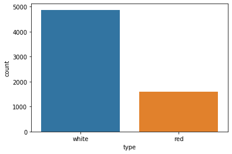

```python
#Annexe(6)
```

#### Parlons maintenant de la variable `quality` qui est la qualité du vin, noté sur 10 :

```python
#Annexe(7)
```

```
6    2820
5    2128
7    1074
4     214
8     192
3      30
9       5
Name: quality, dtype: int64
```

```
array([<matplotlib.axes._subplots.AxesSubplot object at 0x0000027757831438>],
      dtype=object)
```

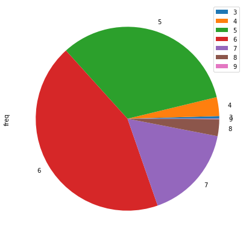

```python
#Annexe(8)
#Diagramme circulaire de la variable quality
```

On observe qu'en moyenne la note de nos vins étudiés est de 5.8/10, que la note la plus faible est de 3/10 et la plus haute de 9/10.  
Grâce au diagramme circulaire, on remarque que les notes principalement données sont 5, 6 et 7 /10.

#### Distributions de nos autres variables :

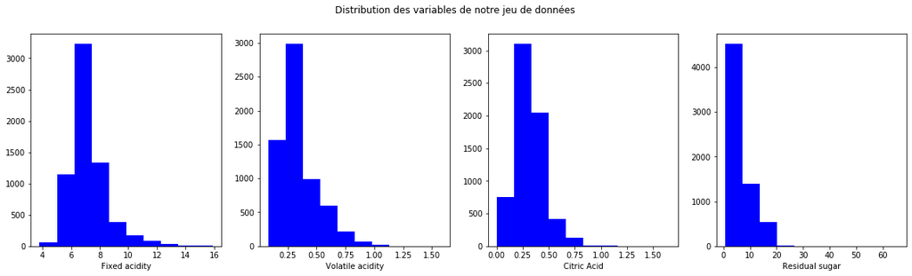

```python
#Annexe(9)
```

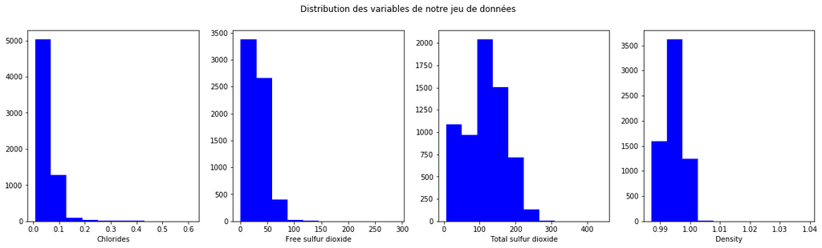

```python
#Annexe(10)
```

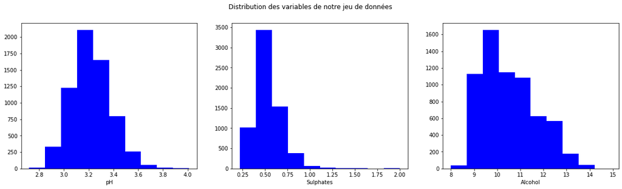

```python
#Annexe(11)
```

## Etudes des variables entre elles

#### Corrélations entre variables

```python
#Annexe(12)
```

|  | fixed acidity | volatile acidity | citric acid | residual sugar | chlorides | free sulfur dioxide | total sulfur dioxide | density | pH | sulphates | alcohol | quality |
| --- | --- | --- | --- | --- | --- | --- | --- | --- | --- | --- | --- | --- |
| fixed acidity | 1.000000 | 0.221066 | 0.323744 | -0.113442 | 0.299104 | -0.283485 | -0.330543 | 0.459713 | -0.251121 | 0.301263 | -0.096190 | -0.076174 |
| volatile acidity | 0.221066 | 1.000000 | -0.377512 | -0.196677 | 0.377995 | -0.353402 | -0.414729 | 0.272101 | 0.260134 | 0.225656 | -0.039528 | -0.266677 |
| citric acid | 0.323744 | -0.377512 | 1.000000 | 0.142324 | 0.039412 | 0.132271 | 0.194398 | 0.097068 | -0.327860 | 0.059070 | -0.010056 | 0.084926 |
| residual sugar | -0.113442 | -0.196677 | 0.142324 | 1.000000 | -0.128814 | 0.403449 | 0.495684 | 0.551494 | -0.266481 | -0.185616 | -0.359132 | -0.034654 |
| chlorides | 0.299104 | 0.377995 | 0.039412 | -0.128814 | 1.000000 | -0.195428 | -0.279602 | 0.363108 | 0.044653 | 0.396240 | -0.257664 | -0.200553 |
| free sulfur dioxide | -0.283485 | -0.353402 | 0.132271 | 0.403449 | -0.195428 | 1.000000 | 0.721476 | 0.025113 | -0.145164 | -0.188947 | -0.179477 | 0.054924 |
| total sulfur dioxide | -0.330543 | -0.414729 | 0.194398 | 0.495684 | -0.279602 | 0.721476 | 1.000000 | 0.031419 | -0.237204 | -0.275878 | -0.264385 | -0.041598 |
| density | 0.459713 | 0.272101 | 0.097068 | 0.551494 | 0.363108 | 0.025113 | 0.031419 | 1.000000 | 0.012525 | 0.260019 | -0.687432 | -0.304447 |
| pH | -0.251121 | 0.260134 | -0.327860 | -0.266481 | 0.044653 | -0.145164 | -0.237204 | 0.012525 | 1.000000 | 0.190864 | 0.120473 | 0.018403 |
| sulphates | 0.301263 | 0.225656 | 0.059070 | -0.185616 | 0.396240 | -0.188947 | -0.275878 | 0.260019 | 0.190864 | 1.000000 | -0.004116 | 0.039054 |
| alcohol | -0.096190 | -0.039528 | -0.010056 | -0.359132 | -0.257664 | -0.179477 | -0.264385 | -0.687432 | 0.120473 | -0.004116 | 1.000000 | 0.444637 |
| quality | -0.076174 | -0.266677 | 0.084926 | -0.034654 | -0.200553 | 0.054924 | -0.041598 | -0.304447 | 0.018403 | 0.039054 | 0.444637 | 1.000000 |

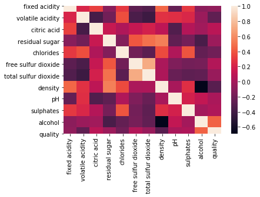

```python
#Annexe(13)
```

Le heatmap sert à nous dire quelles variables sont corrélées entre elles : plus la couleur est claire ou jaune plus les variables sont corrélées entre elles.

# Afin d'aiguiller l'analyse de nos données, nous allons nous poser les questions suivantes :

- Quelles sont les propriétés chimiques qui différencient le vin de haute et de basse qualité ?
- Quelles propriétés chimiques peut-on utiliser pour identifier la couleur du vin ?

Commençons donc par observer la qualité du vin selon sa couleur :

[output not shown]

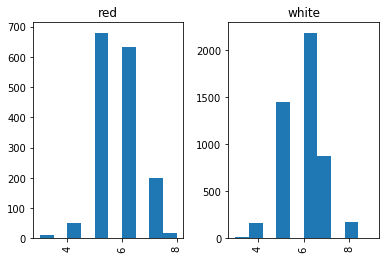

```python
#Annexe(14)
```

L'écart de qualité entre le vin rouge et le vin blanc semble présenter une distribution normale similaire, à l'exception du fait que la distribution du vin blanc présente un pic de qualité autour de la note 6/10, tandis que le vin rouge présente un pic d'environ 5/10.

Comme dis précédemment, la variable `quality`est une variable quantitative, et afin de faire une meilleure analyse nous choisissons de créer une nouvelle variable `cat.quality` qui expliquera si le vin est de bonne qualité (note >= 7), de moyenne qualité (notes 5 et 6) et de mauvaise qualité (note <= 4).

De plus, il est difficile de faire des comparaisons entre le vin blanc et le rouge, en effet nous avons beaucoup plus de vin blanc que de vin rouge : il est donc plus intérressant de prendre au hasard parmi le vin blanc le même nombre de vin que le vin rouge.

```
Taille du dataframe du vin blanc (1593, 14)
Taille du dataframe du vin rouge  (1593, 14)
```

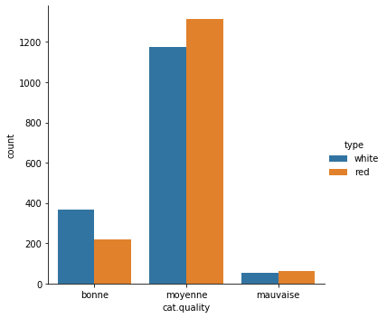

```python
#Annexe(15)
```

On remarque que parmi nos vins, il y a plus de vin rouge de moyenne qualité mais aussi de mauvaise. On voit aussi qu'il y a plus de vin blanc de bonne qualité.

## Commençons par comparer chaque propriété chimique en fonction de la qualité du vin, qu'elle soit bonne ou mauvaise afin d'identifier quelles propriétés chimiques font la différence entre un bon et un mauvais vin.

### Commençons par le vin rouge

```python
#Annexe(16)
```

| cat.quality | fixed acidity | volatile acidity | citric acid | residual sugar | chlorides | free sulfur dioxide | total sulfur dioxide | density | pH | sulphates | alcohol | quality |
| --- | --- | --- | --- | --- | --- | --- | --- | --- | --- | --- | --- | --- |
| bonne | 8.847005 | 0.405530 | 0.376498 | 2.708756 | 0.075912 | 13.981567 | 34.889401 | 0.996030 | 3.288802 | 0.743456 | 11.518049 | 7.082949 |
| mauvaise | 7.895161 | 0.727339 | 0.175000 | 2.665323 | 0.095290 | 12.032258 | 34.500000 | 0.996687 | 3.382258 | 0.590968 | 10.203226 | 3.838710 |
| moyenne | 8.260731 | 0.538406 | 0.258775 | 2.504414 | 0.089043 | 16.328767 | 48.939878 | 0.996874 | 3.310807 | 0.646887 | 10.248427 | 5.482496 |

A l'aide du tableau ci-dessus, on observe qu'il existe des différences entre le vin rouge de bonne et de mauvaise qualité pour les propriétés chimiques suivantes :

- `volatile acidity`
- `citric acid`
- `sulphates`
- `alcohol`

Nous décidons donc d'afficheur leur boxplot :

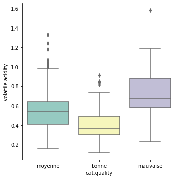

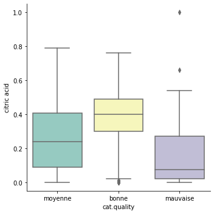

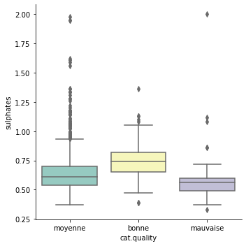

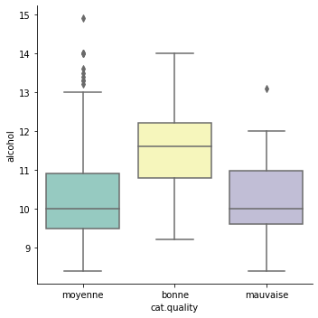

```python
#Annexe(17)
```

### Même analyse que précédemment mais avec le vin blanc

```python
#Annexe(18)
```

| cat.quality | fixed acidity | volatile acidity | citric acid | residual sugar | chlorides | free sulfur dioxide | total sulfur dioxide | density | pH | sulphates | alcohol | quality |
| --- | --- | --- | --- | --- | --- | --- | --- | --- | --- | --- | --- | --- |
| bonne | 6.733243 | 0.257112 | 0.331144 | 5.590463 | 0.038447 | 34.673025 | 126.080381 | 0.992606 | 3.204578 | 0.500027 | 11.329355 | 7.177112 |
| mauvaise | 6.992308 | 0.356154 | 0.286346 | 4.421154 | 0.048231 | 36.384615 | 143.451923 | 0.994067 | 3.222500 | 0.501923 | 10.184615 | 3.884615 |
| moyenne | 6.846550 | 0.279536 | 0.333612 | 6.635477 | 0.047411 | 35.339438 | 141.415247 | 0.994395 | 3.185656 | 0.488458 | 10.280849 | 5.591141 |

A l'aide du tableau ci-dessus, on observe qu'il existe des différences entre le vin blanc de bonne et de mauvaise qualité pour les propriétés chimiques suivantes :

- `volatile acidity`
- `free sulfur dioxide`
- `alcohol`

Nous décidons donc d'afficheur leur boxplot :

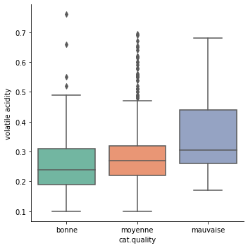

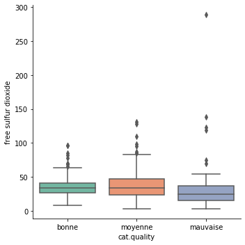

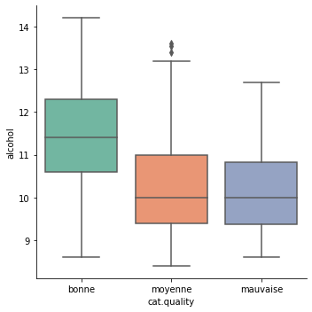

```python
#Annexe(19)
```

## Quelle propriété chimique pouvons-nous utiliser pour différencier le vin rouge du vin blanc sans regarder la couleur ou les noms ?

```python
#Annexe(20)
```

| type | fixed acidity | volatile acidity | citric acid | residual sugar | chlorides | free sulfur dioxide | total sulfur dioxide | density | pH | sulphates | alcohol | quality |
| --- | --- | --- | --- | --- | --- | --- | --- | --- | --- | --- | --- | --- |
| red | 8.326365 | 0.527659 | 0.271551 | 2.538512 | 0.087497 | 15.841808 | 46.463905 | 0.996752 | 3.310590 | 0.657866 | 10.419617 | 5.636535 |
| white | 6.825204 | 0.276871 | 0.331500 | 6.322442 | 0.045372 | 35.220025 | 137.948839 | 0.993972 | 3.191218 | 0.491563 | 10.519266 | 5.900816 |

A l'aide du tableau ci-dessus, on observe qu'il existe des différences entre le vin blanc et le vin rouge pour les propriétés chimiques suivantes :

- `volatile acidity` : le vin blanc est plus faible
- `residual sugar`: le vin blanc a un goût plus sucré en général
- `free` et `total` `sulfur dioxide` : le vin blanc est beaucoup plus élevé
- `density` : le vin blanc est plus faible

On décide alors d'afficher leur violinplot :

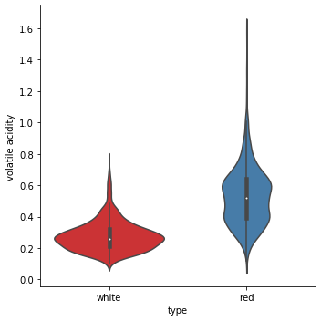

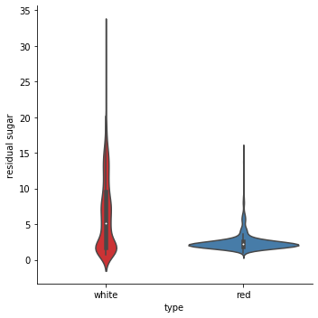

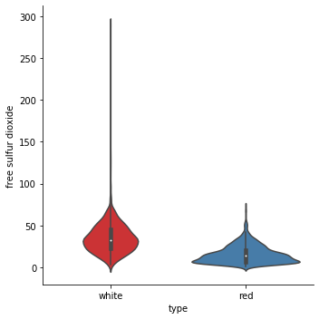

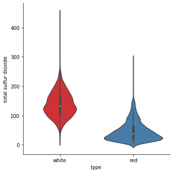

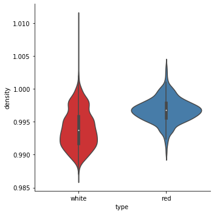

```python
#Annexe(21)
```

## Nous allons maintenant effectuer une régression linéaire afin de savoir quelles propriétés chimiques influent sur la qualité du vin.

On commence par diviser notre jeu de données `data_vin2` en deux : un jeu de données d'apprentissage et un de test.  
Nous allons apprendre le modèle à l'aide d'un échantillon de 80% de nos données et on testera le modèle avec les 20% restants.

On souhaite expliquer la variable `quality`($Y_i$) qui peut être modéliser par une loi de Poisson de paramètre $\lambda_i$ car c'est une variable de comptage qui définit une note sur 10 de la qualité du vin.

Nous étudions donc le modèle suivant :  
$ln(\lambda_i) = \beta_0 + \beta_1 X_{1,i} + ... + \beta_{11} X_{11,i}$

Avec :

- $\beta_0$ qui correspond à l'ordonnée à l'origine du modèle
- les $\beta_k$ pour $k\in[1,11]$ qui sont associés à la i_ème variable explicative
- $X_{k,i}$ qui correspondent aux variables quantitatives de notre étude : ce sont les variables explicatives de notre modèle

```python
#Annexe(22)
```

```
                 Generalized Linear Model Regression Results
==============================================================================
Dep. Variable:                quality   No. Observations:                 2548
Model:                            GLM   Df Residuals:                     2536
Model Family:                 Poisson   Df Model:                           11
Link Function:                    log   Scale:                          1.0000
Method:                          IRLS   Log-Likelihood:                -4711.3
Date:                Sun, 26 Apr 2020   Deviance:                       229.38
Time:                        17:26:03   Pearson chi2:                     227.
No. Iterations:                     4
Covariance Type:            nonrobust
========================================================================================
                           coef    std err          z      P>|z|      [0.025      0.975]
----------------------------------------------------------------------------------------
const                    9.3895     10.377      0.905      0.366     -10.949      29.728
fixed acidity            0.0100      0.014      0.734      0.463      -0.017       0.037
volatile acidity        -0.2387      0.066     -3.599      0.000      -0.369      -0.109
citric acid             -0.0425      0.074     -0.571      0.568      -0.188       0.103
residual sugar           0.0078      0.005      1.684      0.092      -0.001       0.017
chlorides               -0.2056      0.260     -0.792      0.428      -0.714       0.303
free sulfur dioxide      0.0005      0.001      0.730      0.465      -0.001       0.002
total sulfur dioxide    -0.0005      0.000     -1.720      0.085      -0.001    6.53e-05
density                 -8.1962     10.603     -0.773      0.440     -28.978      12.586
pH                       0.0044      0.084      0.053      0.958      -0.160       0.169
sulphates                0.1227      0.063      1.943      0.052      -0.001       0.247
alcohol                  0.0453      0.014      3.157      0.002       0.017       0.073
========================================================================================
```

D'après les résultats obtenu grâce à la fonction `GLM`, on a :

Ce test permet de savoir si nos coefficients sont significatifs ou non, c'est à dire si la variable explicative associée joue un rôle dans la détermination de la qualité d'un vin.

On cherche maintenant à prédire notre jeu de données :

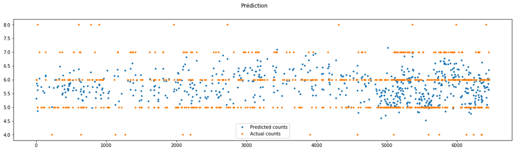

```python
#Annexe(23)
```

# On décide ensuite de faire une CAH pour classer nos vins

Grâce à la régression linéaire précédente, nous avons vu quelles propriétés chimiques influent sur la qualité du vin, on les récupère donc pour faire notre CAH.

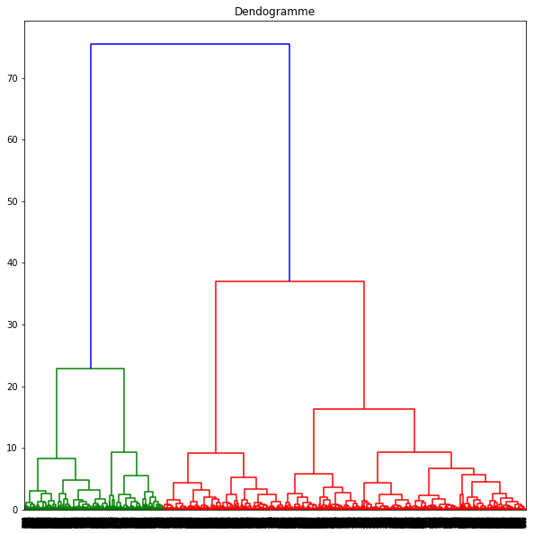

```python
#Annexe(24)
```

[figure not shown]

```python
#Annexe(25)
```

# Annexe

```python
#Annexe(1)
import pandas as pd
import numpy as np
import seaborn as sb
import matplotlib.pyplot as plt

#Pour échantilloner
import random

#Pour régression linéaire
from sklearn.model_selection import train_test_split
import statsmodels.api as sm
from statsmodels.tools import add_constant

#Pour la CAH
from matplotlib import pyplot as plt
from scipy.cluster.hierarchy import dendrogram, linkage, fcluster
from sklearn.cluster import AgglomerativeClustering

%matplotlib inline
```

```python
#Annexe(2)
donnees = pd.read_csv('winequalityN.csv', header = 0, sep = ',')

print('Taille de notre dataframe :', donnees.shape)
donnees.isna().sum()
```

```python
#Annexe(3)
data_vin = pd.read_csv('data_vin.csv', header = 0, sep = ';')
print(data_vin.shape)

data_vin.head()
```

```python
#Annexe(4)
data_vin.describe().round(2)
```

```python
#Annexe(5)
data_vin.type.value_counts()
```

```python
#Annexe(6)
sb.countplot(data_vin.type)
```

```python
#Annexe(7)
data_vin.quality.value_counts()
```

```python
#Annexe(8)
t = pd.crosstab(data_vin.quality, 'freq')
t.plot.pie(subplots=True, figsize = (7, 7))
```

```python
#Annexe(9)
fig = plt.figure(figsize = (20,5))
ax1 = fig.add_subplot(1,4,1)
ax2 = fig.add_subplot(1,4,2)
ax3 = fig.add_subplot(1,4,3)
ax4 = fig.add_subplot(1,4,4)

plt.suptitle('Distribution des variables de notre jeu de données')

ax1.hist(data_vin['fixed acidity'], color = 'b')
ax1.set_xlabel('Fixed acidity')
ax2.hist(data_vin['volatile acidity'], color = 'b')
ax2.set_xlabel('Volatile acidity')
ax3.hist(data_vin['citric acid'], color = 'b')
ax3.set_xlabel('Citric Acid')
ax4.hist(data_vin['residual sugar'], color = 'b')
ax4.set_xlabel('Residual sugar')
```

```python
#Annexe(10)
fig = plt.figure(figsize = (20,5))
ax5 = fig.add_subplot(1,4,1)
ax6 = fig.add_subplot(1,4,2)
ax7 = fig.add_subplot(1,4,3)
ax8 = fig.add_subplot(1,4,4)

plt.suptitle('Distribution des variables de notre jeu de données')

ax5.hist(data_vin['chlorides'], color = 'b')
ax5.set_xlabel('Chlorides')
ax6.hist(data_vin['free sulfur dioxide'], color = 'b')
ax6.set_xlabel('Free sulfur dioxide')
ax7.hist(data_vin['total sulfur dioxide'], color = 'b')
ax7.set_xlabel('Total sulfur dioxide')
ax8.hist(data_vin['density'], color = 'b')
ax8.set_xlabel('Density')
```

```python
#Annexe(11)
fig = plt.figure(figsize = (20,5))
ax9 = fig.add_subplot(1,3,1)
ax10 = fig.add_subplot(1,3,2)
ax11 = fig.add_subplot(1,3,3)

plt.suptitle('Distribution des variables de notre jeu de données')

ax9.hist(data_vin['pH'], color = 'b')
ax9.set_xlabel('pH')
ax10.hist(data_vin['sulphates'], color = 'b')
ax10.set_xlabel('Sulphates')
ax11.hist(data_vin['alcohol'], color = 'b')
ax11.set_xlabel('Alcohol')
```

```python
#Annexe(12)
data_corr = data_vin.corr()
data_corr
```

```python
#Annexe(13)
sb.heatmap(data_corr)
plt.show()
```

```python
#Annexe(14)
data_vin.hist(column = 'quality', by = 'type')
```

```python
#Annexe(15)
cat = pd.Series(np.zeros(data_vin.shape[0]))

cat[data_vin['quality'] == 5] = 'moyenne'
cat[data_vin['quality'] == 6] = 'moyenne'
cat[data_vin['quality'] >= 7] = 'bonne'
cat[data_vin['quality'] <= 4] = 'mauvaise'

data_vin['cat.quality'] = cat

#Echantillonage
data_blanc = data_vin.loc[np.random.choice(data_vin[data_vin['type'] == 'white'].index, 1593, replace=False)]
print('Taille du dataframe du vin blanc', data_blanc.shape)

data_rouge = data_vin[data_vin['type'] == 'red']

print('Taille du dataframe du vin rouge ', data_rouge.shape)

data_vin2 = pd.concat([data_blanc, data_rouge])
sb.catplot(hue = 'type', x = 'cat.quality', data = data_vin2, kind = 'count')
```

```python
#Annexe(16)
data_rouge.groupby('cat.quality').mean()
```

```python
#Annexe(17)
sb.catplot(x = 'cat.quality', y = 'volatile acidity', data = data_rouge, kind = 'box', palette = 'Set3')
sb.catplot(x = 'cat.quality', y = 'citric acid', data = data_rouge, kind = 'box', palette = 'Set3')
sb.catplot(x = 'cat.quality', y = 'sulphates', data = data_rouge, kind = 'box', palette = 'Set3')
sb.catplot(x = 'cat.quality', y = 'alcohol', data = data_rouge, kind = 'box', palette = 'Set3')
```

```python
#Annexe(18)
data_blanc.groupby('cat.quality').mean()
```

```python
#Annexe(19)
sb.catplot(x = 'cat.quality', y = 'volatile acidity', data = data_blanc, kind = 'box', palette = 'Set2')
sb.catplot(x = 'cat.quality', y = 'free sulfur dioxide', data = data_blanc, kind = 'box', palette = 'Set2')
sb.catplot(x = 'cat.quality', y = 'alcohol', data = data_blanc, kind = 'box', palette = 'Set2')
```

```python
#Annexe(20)
data_vin2.groupby(['type']).mean()
```

```python
#Annexe(21)
sb.catplot(x = 'type', y = 'volatile acidity', data = data_vin2, kind = 'violin', palette = 'Set1')
sb.catplot(x = 'type', y = 'residual sugar', data = data_vin2, kind = 'violin', palette = 'Set1')
sb.catplot(x = 'type', y = 'free sulfur dioxide', data = data_vin2, kind = 'violin', palette = 'Set1')
sb.catplot(x = 'type', y = 'total sulfur dioxide', data = data_vin2, kind = 'violin', palette = 'Set1')
sb.catplot(x = 'type', y = 'density', data = data_vin2, kind = 'violin', palette = 'Set1')
```

```python
#Annexe(22)
#Définition de nos variables à étudier
Y = data_vin2['quality']
X = data_vin2[data_vin2.columns[1:12]]

#Décomposition en deux jeux de données, un jeu 'train' et un jeu de test
X_train, X_test, Y_train, Y_test = train_test_split(X, Y, test_size = 0.2)

#On ajoute une constante pour effectuer notre régression car GLM fait la régression sans constante par défault
X_train_beta0 = sm.tools.add_constant(X_train)

#Régression linéaire de poisson :
reg_poiss = sm.GLM(Y_train, X_train_beta0, family=sm.families.Poisson()).fit()
print(reg_poiss.summary())
```

```python
#Annexe(23)
X_test_beta0 = sm.tools.add_constant(X_test)

pred_poiss = reg_poiss.get_prediction(X_test_beta0)
predictions_frame = pred_poiss.summary_frame()

predicted_counts = predictions_frame['mean']
actual_counts = Y_test
fig = plt.figure(figsize = (20,5))
fig.suptitle('Prédiction')
predicted, = plt.plot(X_test.index, predicted_counts, '.', label='Predicted counts')
actual, = plt.plot(X_test.index, actual_counts, '.', label='Actual counts')
plt.legend(handles=[predicted, actual])
plt.show()
```

```python
#Annexe(24)
X = data_vin2.filter(['type','volatile acidity', 'sulphates', 'alcohol'])

Z = linkage(X.filter(['volatile acidity', 'sulphates', 'alcohol']),method='ward',metric='euclidean')

#Affichage du dendrogramme
plt.figure(figsize = (10,10))
plt.title('Dendogramme')
dendrogram(Z,labels=data_vin2.index)
plt.show()
```

```python
#Annexe(25)
cluster = AgglomerativeClustering(n_clusters=2, affinity='euclidean', linkage='ward')
pred = cluster.fit_predict(X.filter(['volatile acidity', 'alcohol', 'sulphates']))

fig = plt.figure(figsize = (20,5))
ax1 = fig.add_subplot(1,4,1)
ax2 = fig.add_subplot(1,4,2)
ax3 = fig.add_subplot(1,4,3)
ax4 = fig.add_subplot(1,4,4)

ax1.scatter(X.iloc[:,0], X.iloc[:,1], c=cluster.labels_, cmap='rainbow')
ax1.set_xlabel('Type du vin')
ax1.set_ylabel('Volatile acidity')

ax2.scatter(X.iloc[:,1], X.iloc[:,2], c=cluster.labels_, cmap='rainbow')
ax2.set_xlabel('Volatile acidity')
ax2.set_ylabel('Alcohol')

ax3.scatter(X.iloc[:,1], X.iloc[:,3], c=cluster.labels_, cmap='rainbow')
ax3.set_xlabel('Volatile acidity')
ax3.set_ylabel('Sulphates')

ax4.scatter(X.iloc[:,2], X.iloc[:,3],c=cluster.labels_, cmap='rainbow')
ax4.set_xlabel('Alcohol')
ax4.set_ylabel('Sulphates')
```